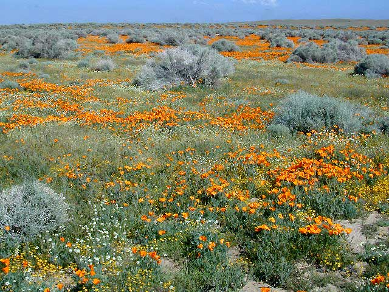

### Magnet hypothesis: plant-pollinator interactions

**Purpose:** A test of the magnet hypothesis was examined in Mojave National Preserve by Ally Ruttan.

**Hypothesis:** Floral resource island created by shrubs and the associated beneficiary annual plants will positively and non-additively influence pollinator visitation rates.

**Predictions:**  
(1) The frequency and duration of pollinator visitations to annuals is greater under shrubs than in the paired-open microsites (magnet H because of concentration).  
(2) Annual plants under flowering entomophilous shrubs (*Larrea tridentata*) will have a higher frequency and duration of pollinator visitations than annual plants under anemophilous shrubs (*Ambrosia dumosa*) because of higher concentrations of suitable floral resources for pollinators (specificity of pollinator faciliation).  
(3) Shrubs with annuals in their understory will have a higher frequency and duration of pollinator visitations than shrubs without annuals due to increased concentrations of floral resources for pollinators (reverse magnet effect and reciprocal benefits).

An interesting corollary is that there are appropriate floral resources for desert pollinators, that they discriminate, and that entomophilous and anemophilous shrubs facilitate flowering similarly.

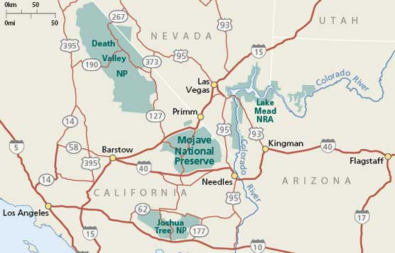

```r
#libraries####
library(tidyverse)
library(DT)
library(lubridate)
library(ggpubr)
library(glmmTMB)
library(car)
library(performance)
library(emmeans)
```

```r
#meta-data####
meta <- read_csv("data/meta-data.csv")
datatable(meta)
```

|  | attribute | description |
| --- | --- | --- |
| 1 | Recorder | Person who watched videos and gathered data |
| 2 | Video ID | Name of actual video clip/file, or in-situ period |
| 3 | Day | Day of experiment that video was taken (corresponds to date) |
| 4 | Date | Date video was taken |
| 5 | Treatment | SA (Visits to Larrea shrub flowers with annuals present), SAA (Visits to annuals under flowering Larrea shrub), SX(Visits to Larrea shrub flowers with no annuals present under shrub), OA(open area wit… |
| 6 | Replicate | 4 replicates per treatment per day |
| 7 | Name | Combination of Day, treatment, and replicate; A unique name for each plot used for data collection |
| 8 | plant species | D (Desert Dandelion, Malacorthrix glabrata), L (Creosote shrub, Larrea tridentata) |
| 9 | RTU | small fly SF, big fly BF, small bee SB, medium bee MB, big bee BB, beetle B, Lepidoptera L, Hemiptera H, Wasp W, Ant A, Bird BI, Odonota O, Spider S etc) |
| 10 | total video duration | The full duration of the video, or in-situ observation period |

[output cut: 5 more lines]

```r
#error is SD

#shrub dimensions####
shrubs <- read_csv("data/shrubs.csv")

shrubs <- shrubs %>%
  mutate(
    date = dmy(date),
    year = year(date),
    day = day(date)
  )


#data####
data.2015 <- read_csv("data/MNP.2015.csv")
data.2016 <- read_csv("data/MNP.2016.csv")

#merge
data <- rbind.data.frame(data.2015, data.2016)

#code treatment properly
data <- data %>% rename(net.treatment = treatment) #%>% na.omit(data)

#keep key columns and minimize working dataframe
data <- data %>% select(-name, -plant, -start, -stop, -ID, -recorder, -shrub.x, -shrub.y, -shrub.z) %>%
  mutate(date = mdy(date),
  day = day(date))


#join data with shrub data
data <- data %>%
  left_join(shrubs, by = c("year", "day", "date", "rep", "net.treatment"))

#set year and rep as characters
data$year <- as.character(data$year)
data$rep <- as.character(data$rep)


#convert times to total seconds then to hour
data$total.duration <- (as.numeric(data$total.duration))/3600
data$visitation.duration <- (as.numeric(data$visitation.duration))/3600


#recode net.treatment column and separate observation types
data <- data %>% mutate(
  net.treatment = ifelse(net.treatment %in% c("SA"), "Larrea flowers with annuals",
                         ifelse(net.treatment %in% c("SX"), "Larrea flowers without annuals",
                                ifelse(net.treatment %in% c("SAA"), "Annual flowers under Larrea",
                                       ifelse(net.treatment %in% c("OA"), "Annual flowers in open",
                                              ifelse(net.treatment %in% c("AMB"), "Annual flowers under Ambrosia","NA"))))),
  observation.type = ifelse(floral.density == 200, "in-situ", "video"),
  shrub.volume = 4/3 * pi * shrub.x * shrub.y * shrub.z)


heights <- data %>%
  group_by(year, day, net.treatment, rep) %>%
  summarise(height = mean(shrub.z),
            width = mean(shrub.x),
            length = mean(shrub.y)) %>%
  mutate(species = ifelse(net.treatment %in% c("Larrea flowers without annuals", "Annual flowers under Larrea"), "Larrea",
                   ifelse(net.treatment %in% c("Annual flowers under Ambrosia"), "Ambrosia", "NA"))) %>%
  filter(height > 0, net.treatment != "Larrea flowers with annuals") %>%
  group_by(species) %>%
  summarise(mean.height = mean(height),
            n = length(height))


#frequency wrangled by RTU####
#total.duration has two values for each replicate only if film was divided into two files, I've summed them here.
frequency <- data %>%
  group_by(year, day, net.treatment, rep, insect.RTU, observation.type, shrub.volume) %>%
  summarise(net.time = sum(unique(total.duration)),
            mean.temp = mean(temperature),
            mean.var.temp = mean(error),
            net.visitation = sum(visitation.duration),
            mean.visitation.duration = mean(visitation.duration),
            floral.density = mean(floral.density),
            insect.richness = n_distinct(insect.RTU),
            count = n()) %>%
  ungroup() %>%
  pivot_wider(
    names_from = insect.RTU,
    values_from = c(net.visitation, mean.visitation.duration, count),
    values_fill = list(net.visitation = 0, mean.visitation.duration = 0, count = 0)
  ) %>%
  pivot_longer(
    cols = starts_with(c("net.visitation", "mean.visitation.duration", "count")),
    names_to = c(".value", "insect.RTU"),
    names_sep = "_"
  ) %>%
  #extrapolations cannot be easily made from times of less than 15 minutes, particularly for videos being compared to 1 hour+ of film
  filter(net.time >= 0.25 & insect.RTU != "none")

#rates needed
frequency <- frequency %>% mutate(rate.per.flower = (count/floral.density))

#site ids are needed to group variables by site
days.all <- frequency %>% group_by(year, day, rep) %>%
  #function doesn't matter, only getting the unique set of year, day, and rep
  summarise(count = n()) %>%
  select(-count) %>%
  ungroup() %>%
  rowid_to_column(var = "site.id")

frequency <- frequency %>% left_join(days.all, by = c("year", "day", "rep"))


#view frequency data
datatable(frequency)
```

|  | year | day | net.treatment | rep | observation.type | shrub.volume | net.time | mean.temp | mean.var.temp | floral.density | insect.richness | insect.RTU | net.visitation | mean.visitation.duration | count | rate.per.flower | site.id |
| --- | --- | --- | --- | --- | --- | --- | --- | --- | --- | --- | --- | --- | --- | --- | --- | --- | --- |
| 1 | 2015 | 1 | Annual flowers in open | 1 | video | 0 | 1.51416666666667 | 29.45622222 | 3.412740449 | 30 | 1 | bees | 0.4825 | 0.0193 | 25 | 0.833333333333333 | 1 |
| 2 | 2015 | 1 | Annual flowers in open | 1 | video | 0 | 1.51416666666667 | 29.45622222 | 3.412740449 | 30 | 1 | flies | 0.09 | 0.01 | 9 | 0.3 | 1 |
| 3 | 2015 | 1 | Annual flowers in open | 1 | video | 0 | 1.51416666666667 | 29.45622222 | 3.412740449 | 30 | 1 | other | 0.00805555555555556 | 0.00805555555555556 | 1 | 0.0333333333333333 | 1 |
| 4 | 2015 | 1 | Annual flowers in open | 1 | in-situ | 0 | 0.25 | 29.45622222 | 3.412740449 | 200 | 1 | bees | 0 | 0 | 0 | 0 | 1 |
| 5 | 2015 | 1 | Annual flowers in open | 1 | in-situ | 0 | 0.25 | 29.45622222 | 3.412740449 | 200 | 1 | flies | 0 | 0 | 0 | 0 | 1 |
| 6 | 2015 | 1 | Annual flowers in open | 1 | in-situ | 0 | 0.25 | 29.45622222 | 3.412740449 | 200 | 1 | other | 0 | 0 | 0 | 0 | 1 |
| 7 | 2015 | 1 | Annual flowers in open | 2 | video | 0 | 1.61972222222222 | 29.45622222 | 3.412740449 | 26 | 1 | bees | 0.000833333333333333 | 0.000416666666666667 | 2 | 0.0769230769230769 | 2 |
| 8 | 2015 | 1 | Annual flowers in open | 2 | video | 0 | 1.61972222222222 | 29.45622222 | 3.412740449 | 26 | 1 | flies | 0.0936111111111111 | 0.0156018518518519 | 6 | 0.230769230769231 | 2 |
| 9 | 2015 | 1 | Annual flowers in open | 2 | video | 0 | 1.61972222222222 | 29.45622222 | 3.412740449 | 26 | 1 | other | 0 | 0 | 0 | 0 | 2 |
| 10 | 2015 | 1 | Annual flowers in open | 2 | in-situ | 0 | 0.25 | 29.45622222 | 3.412740449 | 200 | 1 | bees | 0 | 0 | 0 | 0 | 2 |

[output cut: 1106 more lines]

```r
#separate net.treatment to individual vectors/factors
#Expt 1. Single-magnet hypothesis
expt1 <- frequency %>% filter(net.treatment == "Annual flowers under Larrea" | net.treatment == "Annual flowers in open" | net.treatment == "Annual flowers under Ambrosia")

expt1 <- expt1 %>% mutate(microsite = ifelse(net.treatment %in% c("Annual flowers under Larrea"), "Larrea",
                                             ifelse(net.treatment %in% c("Annual flowers under Ambrosia"), "Ambrosia",
                                                    ifelse(net.treatment %in% c("Annual flowers in open"), "open", "NA"))))

#by observation type
expt1.video = expt1 %>% filter(observation.type == "video") %>%
  mutate(duration.hour = net.visitation/net.time)

#by years
expt1.2015.video <- expt1 %>% filter(year == 2015 & observation.type == "video")
expt1.2016 <- expt1 %>% filter(year == 2016) #no in-situ for 2016

#Expt2. Shrub flower-annual interactions through pollinators
expt2 <- frequency %>% filter(net.treatment == "Larrea flowers with annuals" | net.treatment == "Larrea flowers without annuals")

expt2 <- expt2 %>% mutate(treatment = ifelse(net.treatment %in% c("Larrea flowers with annuals"), "Larrea + annuals",
                                             ifelse(net.treatment %in% c("Larrea flowers without annuals"), "Larrea - annuals", "NA")))

expt2.insitu = expt2 %>% filter(observation.type == "in-situ" ) %>%
  #no "other" insects were observed in 2016, so remove from 2016 but not 2015
  filter(year == 2015|insect.RTU != "other")

expt2.2015.insitu <- expt2.insitu %>% filter(year == 2015)
expt2.2016 <- expt2 %>% filter(year == 2016 & insect.RTU != "other") #no video for 2016

#Summary Stats
expt1.video %>%
  group_by(year, insect.RTU) %>%
  summarise(sum = sum(count),
            video = sum(unique(net.time)))
```

```
## # A tibble: 6 x 4
## # Groups:   year [2]
##   year  insect.RTU   sum video
##   <chr> <chr>      <int> <dbl>
## 1 2015  bees         558  87.2
## 2 2015  flies        221  87.2
## 3 2015  other         59  87.2
## 4 2016  bees        2287  98.1
## 5 2016  flies        241  98.1
## 6 2016  other         50  98.1
```

```r
expt2.insitu %>%
  group_by(year, insect.RTU) %>%
  summarise(sum = sum(count))
```

```
## # A tibble: 5 x 3
## # Groups:   year [2]
##   year  insect.RTU   sum
##   <chr> <chr>      <int>
## 1 2015  bees         127
## 2 2015  flies         57
## 3 2015  other         26
## 4 2016  bees         126
## 5 2016  flies         24
```

```r
#Data structure: A total of 4 dataframes, two experiments, two years each

map <- read_csv("data/locations.csv")
map
```

```
## # A tibble: 5 x 3
##    site   lat  long
##   <dbl> <dbl> <dbl>
## 1     1  35.4 -115.
## 2     2  35.3 -115.
## 3     3  35.4 -115.
## 4     4  35.4 -115.
## 5     5  35.1 -116.
```

```r
#data collected using hobos
data.temp <- read_csv("data/hobodata.csv")
#format date, get year, hour, and day. Remove spurious temperatures
data.temp <- data.temp %>%
  mutate(date = mdy(date),
    year = lubridate::year(date),
    hour = hour(time),
    day = day(date)) %>%
  filter(temperature > -50)

data.temp$year <- as.character(data.temp$year)

#reformat 2015 codings
data.temp.2015 <- data.temp %>%
  filter(year == 2015) %>%
  separate(treatment,
           into = c("shrub", "net.treatment", "rep"),
           sep = "-") %>%
  filter(!(shrub == "A" & net.treatment == "S")) %>%
  dplyr::select(-shrub) %>%
  mutate(site.id = rep)

#reformat 2016 codings
data.temp.2016 <- data.temp %>%
  filter(year == 2016) %>%
  separate(treatment,
           into = c("net.treatment", "rep"),
           sep = " ") %>%
  mutate(site.id = rep)

#numbering reps as unique ids
data.temp.2016$rep <- as.numeric(data.temp.2016$rep) + 6

#rename variables
hobo.temp <- rbind(data.temp.2015, data.temp.2016) %>%
  mutate(
    net.treatment = ifelse(net.treatment %in% c("OPEN", "O"), "open",
                                ifelse(net.treatment %in% c("SX"), "Larrea without annuals",
                                       ifelse(net.treatment %in% c("SA", "S"), "Larrea with annuals",
                                              ifelse(net.treatment %in% c("AMB"), "Ambrosia", NA
                                                     #ifelse(net.treatment %in% c("S"), "Larrea", "NA")
                                                     )))),
         shrub.volume = 4/3 * pi * x1 * x2 * x3) %>%
  dplyr::select(-x1,-x2,-x3)

#remove NAs
hobo.temp <- hobo.temp[!is.na(hobo.temp$net.treatment),]


#average temperature per day during the collecting period
temperature.collected <- hobo.temp %>%
  filter(date %in% data$date & hour >= 10 & hour <= 12) %>%
  group_by(net.treatment, day, site.id, year) %>%
  summarise(temperature = mean(temperature)) %>%
  mutate(type = "collection")
#Average temperature per day during the study period
hobo.temp.day <- hobo.temp %>%
  group_by(year, net.treatment, day, site.id) %>%
  summarise(temperature =  mean(temperature)) %>%
  mutate(type = "study period")
```

```r
hobo.temp.graph <- rbind(temperature.collected, hobo.temp.day)

#environmental data from the previous season
data.weather <- read_csv("data/WRCC weather data.csv")
data.weather$date <- mdy(data.weather$date)
data.weather$year <- as.character(data.weather$year)

#delineate each growing season
data.weather <- data.weather %>%
  mutate(rainy.season = ifelse(year == 2016, "grow.2016",
                                 ifelse(year == 2014, "grow.2015",
                                        ifelse(year == 2015 & day.year < 122, "grow.2015",
                                               ifelse(year == 2015 & day.year > 304, "grow.2016", NA))))) %>%
  na.omit()

#summaries of different environmental variables
data.weather %>% group_by(rainy.season) %>%
  summarize(mean.temp = mean(mean.temp),
            mean.precipitation = mean(precipitation),
            precipitation = sum(precipitation),
            radiation = mean(radiation))
```

```
## # A tibble: 2 x 5
##   rainy.season mean.temp mean.precipitation precipitation radiation
##   <chr>            <dbl>              <dbl>         <dbl>     <dbl>
## 1 grow.2015         12.2              0.508          91.9      378.
## 2 grow.2016         10.6              0.553         101.       374.
```

```r
# environment <- data.weather %>%
#   dplyr::select(year, date, rainy.season, mean.temp, radiation, precipitation) %>%
#   pivot_longer(cols = c(mean.temp, radiation, precipitation),
#                               names_to = "variable",
#                               values_to = "value")
```

```r
# #just one point
# map <- map %>% filter(lat < 35.3)
#
# require(ggmap)
# cali <- get_map(location = c(lon = -115.6, lat = 35.06), zoom = 10)
# #cali <-get_googlemap("california", crop= FALSE, zoom = 10)
# p <-ggmap(cali)
# p + geom_point(data=map, aes(x=long, y=lat), alpha = .25, size = 6, color = "blue")
#
# #really zoomed out
# cali <- get_map(location = c(lon = -115.6, lat = 35.06), zoom = 9)
# p <-ggmap(cali)
# p + geom_point(data=map, aes(x=long, y=lat), alpha = .25, size = 4, color = "blue")
```

### Data visualization

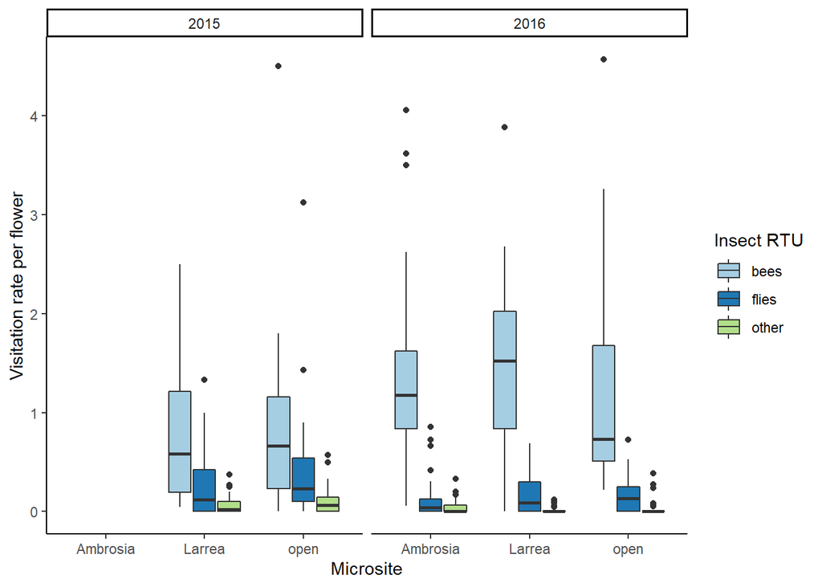

```r
#expt1####
#visitations####
ggplot(expt1.video, aes(microsite, rate.per.flower, fill = insect.RTU)) +
  geom_boxplot() +
  ylab("Visitation rate per flower") +
  xlab("Microsite") +
  scale_fill_brewer(name = "Insect RTU", palette = "Paired") +
  facet_grid(~year) +
  theme_classic() +
  ggsave("Tables and Figures\\Figure 1 flowering rate per microsite.pdf", height = 5, width = 7)
```

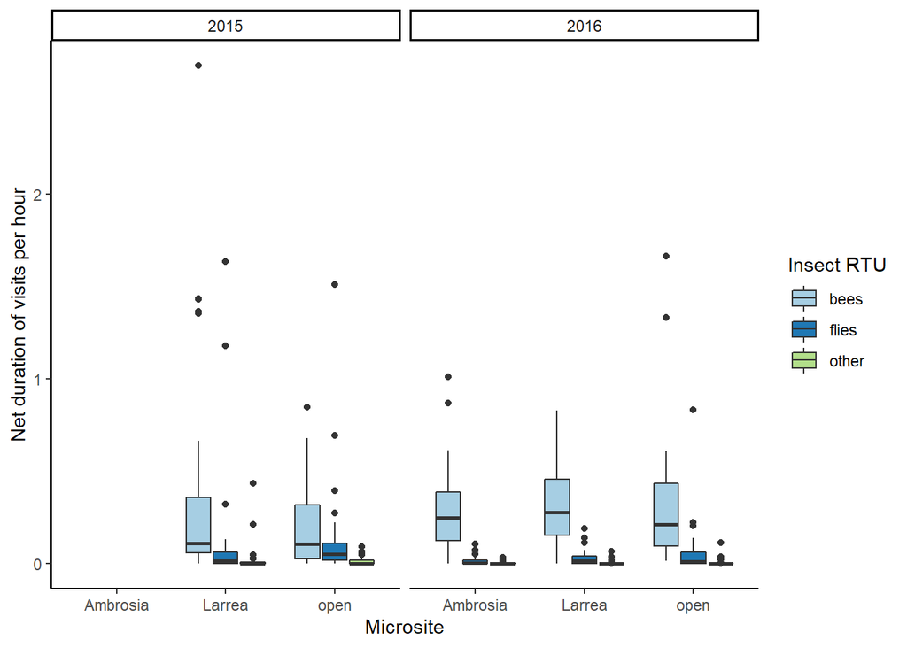

```r
#visit durations####
#net visitation time
ggplot(expt1.video , aes(microsite, net.visitation, fill = insect.RTU)) +
  geom_boxplot() +
  ylab("Net duration of visits per hour") +
  xlab("Microsite") +
  scale_fill_brewer(name = "Insect RTU", palette = "Paired") +
  facet_grid(~year) +
  theme_classic() +
  ggsave("Tables and Figures/Figure 2 net duration per hour.pdf", height = 5, width = 7)
```

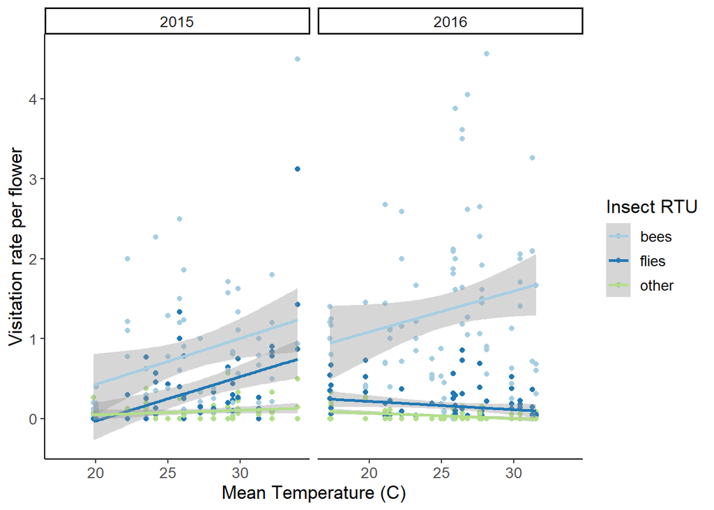

```r
#temperature####
ggplot(expt1.video, aes(mean.temp, rate.per.flower, color = insect.RTU)) +
  geom_point() +
  ylab("Visitation rate per flower") +
  xlab("Mean Temperature (C)") +
  geom_smooth(method = "lm") +
  facet_wrap(~year) +
  scale_color_brewer(name = "Insect RTU", palette = "Paired") +
  theme_classic() +
  theme(text = element_text(size = 13)) +
  ggsave("Tables and Figures/Figure S2 Malacothrix visitation rate per temperature.pdf", width = 7, height = 5)
```

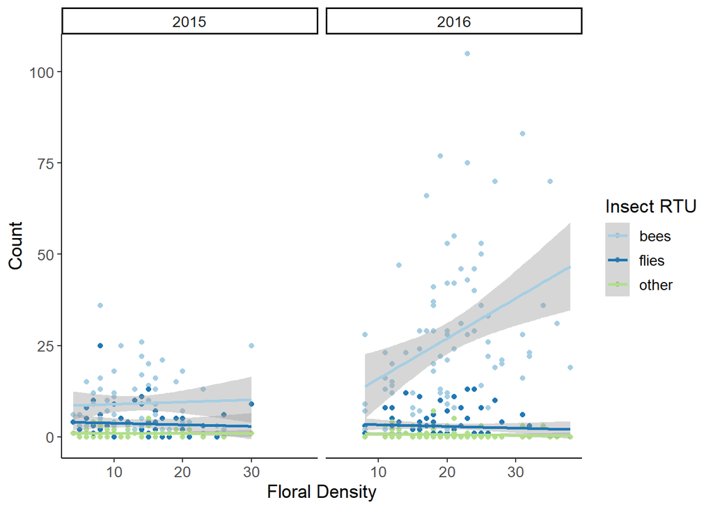

```r
#floral density####
ggplot(expt1.video, aes(floral.density, count, color = insect.RTU)) +
  geom_point() +
  ylab("Count") +
  xlab("Floral Density") +
  geom_smooth(method = "lm") +
  facet_wrap(~year) +
  scale_color_brewer(name = "Insect RTU", palette = "Paired") +
  theme_classic() +
  theme(text = element_text(size = 13)) +
  ggsave("Tables and Figures/Figure S4 Floral Density.pdf", width = 7, height = 4)
```

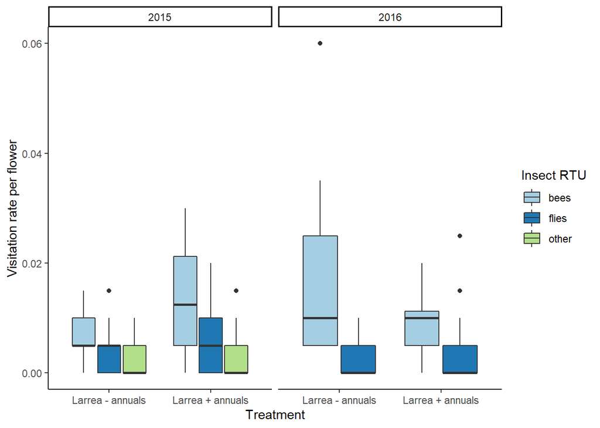

```r
#expt2####
#visitations####
ggplot(expt2.insitu, aes(treatment, rate.per.flower, fill = insect.RTU)) +
  geom_boxplot() +
  ylab("Visitation rate per flower") +
  xlab("Treatment") +
  scale_fill_brewer(name = "Insect RTU", palette = "Paired") +
  facet_grid(~year) +
  theme_classic() +
  ggsave("Tables and Figures/Figure 3 flowering rate per larrea treatment.pdf", height = 5, width = 7)
```

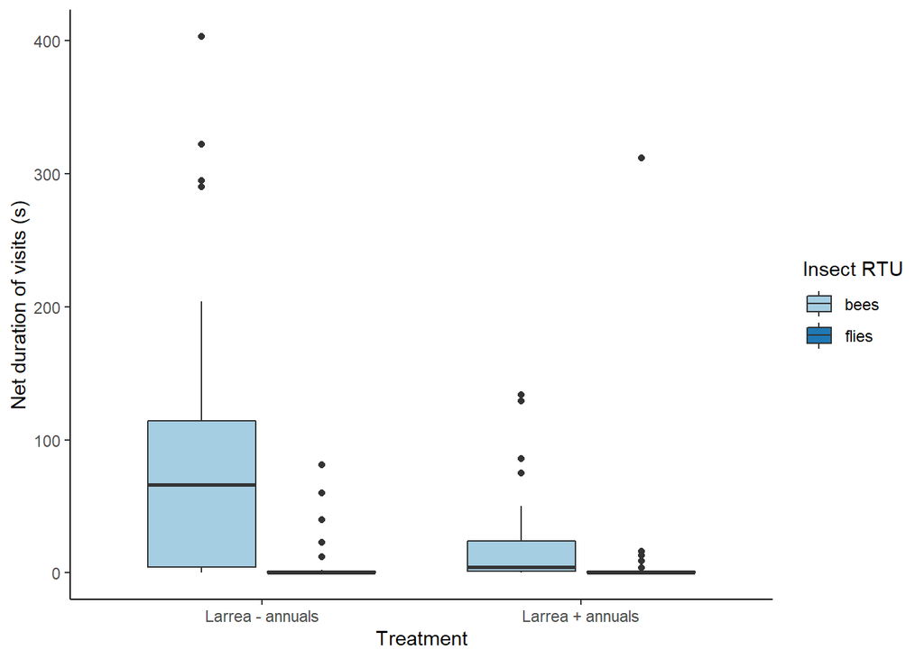

```r
#visit durations####
ggplot(expt2.2016, aes(treatment, net.visitation * 3600, fill = insect.RTU)) +
  geom_boxplot() +
  ylab("Net duration of visits (s)") +
  xlab("Treatment") +
  scale_fill_brewer(name = "Insect RTU", palette = "Paired") +
  theme_classic() +
  ggsave("Tables and Figures/Figure 4 duration per larrea treatment.pdf", width = 8, height = 5)
```

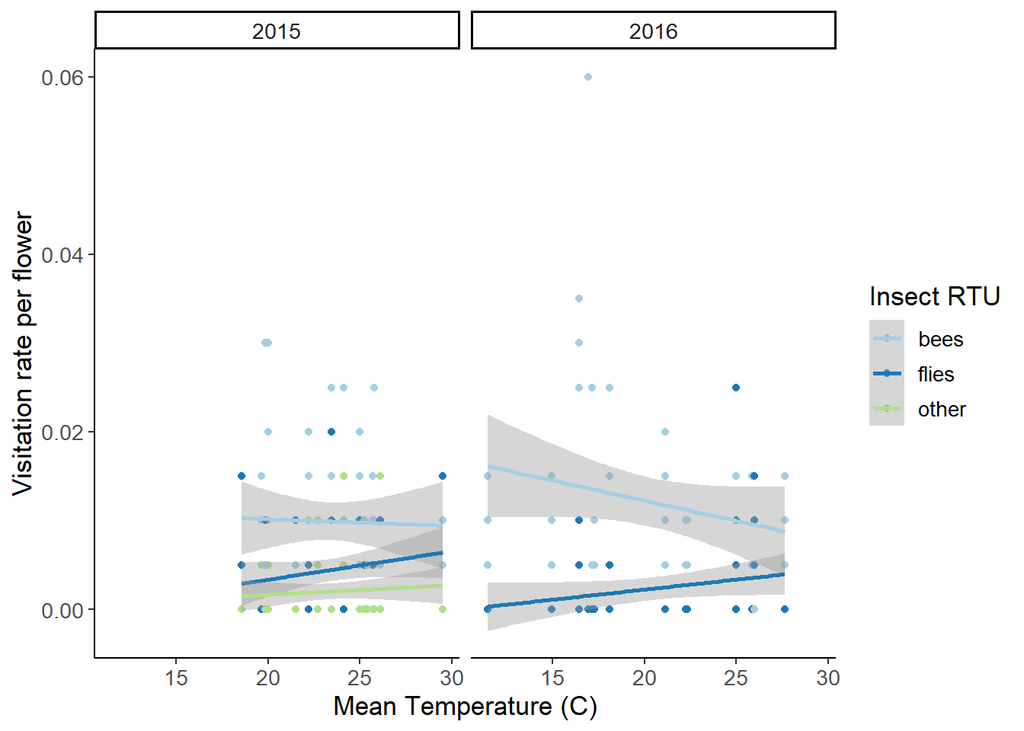

```r
#temperature####
ggplot(expt2.insitu, aes(mean.temp, rate.per.flower, color = insect.RTU)) +
  geom_point() +
  ylab("Visitation rate per flower") +
  xlab("Mean Temperature (C)") +
  geom_smooth(method = "lm") +
  facet_wrap(~year) +
  scale_color_brewer(name = "Insect RTU", palette = "Paired") +
  theme_classic() +
  theme(text = element_text(size = 13)) +
  ggsave("Tables and Figures/Figure S3 Larrea visitation rate per termperature.pdf", width = 7, height = 5)
```

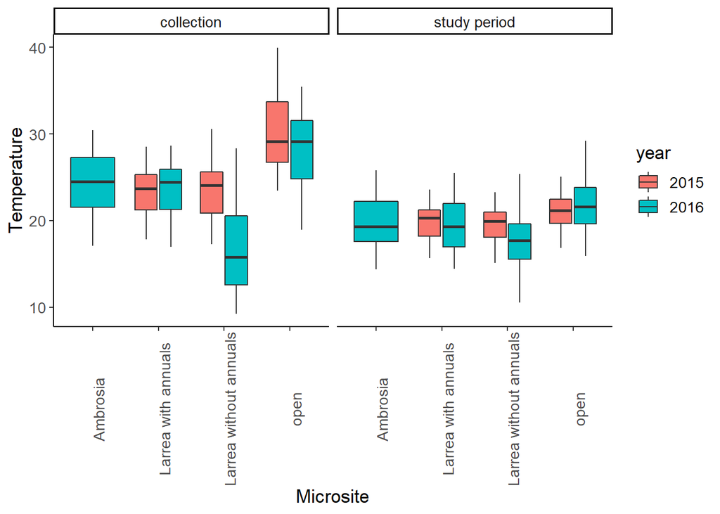

```r
#The effect of microsite on temperature during collection
ggplot(hobo.temp.graph, aes(net.treatment, temperature, fill = year)) +
  geom_boxplot() +
  facet_grid(.~ type) +
  theme_classic() +
  ylab("Temperature") +
  xlab("Microsite") +
  theme(axis.text.x = element_text(angle = 90),
        text = element_text(size = 13)) +
  ggsave("Tables and Figures/Figure S6 Temperature per microsite.pdf")
```

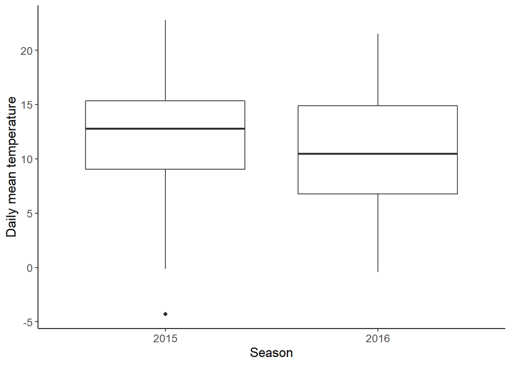

```r
#Temperature over the rainy season
ggplot(data.weather, aes(rainy.season, mean.temp)) +
  geom_boxplot() +
  theme_classic() +
  ylab("Daily mean temperature") +
  xlab("Season") +
  theme(text = element_text(size = 13)) +
  scale_x_discrete(labels = c("grow.2015" = "2015", "grow.2016" = "2016")) +
  ggsave("Tables and Figures/Figure S5 Environment during rainy season.pdf")
```

```r
#Additive-term models for all insect taxa####
#expt1####
#2015####
#visitations
m <- glmmTMB(rate.per.flower ~ microsite * insect.RTU + mean.temp + offset(net.time) + (1|site.id) + (1|day), family = "poisson", data = expt1.2015.video)

check_overdispersion(m) #not overdispersed
```

```
## # Overdispersion test
##
##        dispersion ratio =  0.314
##   Pearson's Chi-Squared = 54.599
##                 p-value =      1
```

```r
check_zeroinflation(m) #not zero-inflated
```

```
## # Check for zero-inflation
##
##    Observed zeros: 42
##   Predicted zeros: 130
##             Ratio: 3.10
```

```r
Anova(m, test = "Chisq")
```

```
## Analysis of Deviance Table (Type II Wald chisquare tests)
##
## Response: rate.per.flower
##                       Chisq Df Pr(>Chisq)
## microsite             8.647  1   0.003276 **
## insect.RTU           29.983  2  3.086e-07 ***
## mean.temp            15.242  1  9.455e-05 ***
## microsite:insect.RTU  0.636  2   0.727610
## ---
## Signif. codes:  0 '***' 0.001 '**' 0.01 '*' 0.05 '.' 0.1 ' ' 1
```

```r
emmeans(m, pairwise~insect.RTU, adjust="tukey")
```

```
## $emmeans
##  insect.RTU emmean    SE  df lower.CL upper.CL
##  bees       -0.364 0.173 174   -0.706  -0.0219
##  flies      -1.252 0.245 174   -1.736  -0.7677
##  other      -2.630 0.458 174   -3.535  -1.7257
##
## Results are averaged over the levels of: microsite
## Results are given on the log (not the response) scale.
## Confidence level used: 0.95
##
## $contrasts
##  contrast      estimate    SE  df t.ratio p.value
##  bees - flies     0.888 0.265 174 3.348   0.0029
##  bees - other     2.266 0.469 174 4.830   <.0001
##  flies - other    1.378 0.500 174 2.755   0.0178
##
## Results are averaged over the levels of: microsite
## Results are given on the log (not the response) scale.
## P value adjustment: tukey method for comparing a family of 3 estimates
```

```r
emmeans(m, pairwise~microsite, adjust="tukey")
```

```
## $emmeans
##  microsite emmean    SE  df lower.CL upper.CL
##  Larrea    -0.728 0.334 174    -1.39  -0.0682
##  open      -2.103 0.366 174    -2.83  -1.3815
##
## Results are averaged over the levels of: insect.RTU
## Results are given on the log (not the response) scale.
## Confidence level used: 0.95
##
## $contrasts
##  contrast      estimate    SE  df t.ratio p.value
##  Larrea - open     1.38 0.575 174 2.392   0.0178
##
## Results are averaged over the levels of: insect.RTU
## Results are given on the log (not the response) scale.
```

```r
#visit duration####
shapiro.test(expt1.2015.video$net.visitation) #not normal
```

```
##
##  Shapiro-Wilk normality test
##
## data:  expt1.2015.video$net.visitation
## W = 0.47281, p-value < 2.2e-16
```

```r
m <- glmmTMB(net.visitation~microsite*insect.RTU + mean.temp + offset(net.time) + (1|site.id) + (1|day), family = "tweedie", data = expt1.2015.video)

Anova(m, test = "Chisq")
```

```
## Analysis of Deviance Table (Type II Wald chisquare tests)
##
## Response: net.visitation
##                        Chisq Df Pr(>Chisq)
## microsite             4.3908  1    0.03613 *
## insect.RTU           83.1414  2    < 2e-16 ***
## mean.temp             3.9203  1    0.04771 *
## microsite:insect.RTU  3.3847  2    0.18408
## ---
## Signif. codes:  0 '***' 0.001 '**' 0.01 '*' 0.05 '.' 0.1 ' ' 1
```

```r
emmeans(m, pairwise~insect.RTU, adjust="tukey")
```

```
## $emmeans
##  insect.RTU emmean    SE  df lower.CL upper.CL
##  bees        -1.36 0.199 172    -1.75   -0.968
##  flies       -2.38 0.232 172    -2.84   -1.925
##  other       -4.11 0.286 172    -4.68   -3.547
##
## Results are averaged over the levels of: microsite
## Results are given on the log (not the response) scale.
## Confidence level used: 0.95
##
## $contrasts
##  contrast      estimate    SE  df t.ratio p.value
##  bees - flies      1.02 0.255 172 4.015   0.0003
##  bees - other      2.75 0.304 172 9.064   <.0001
##  flies - other     1.73 0.325 172 5.317   <.0001
##
## Results are averaged over the levels of: microsite
## Results are given on the log (not the response) scale.
## P value adjustment: tukey method for comparing a family of 3 estimates
```

```r
emmeans(m, pairwise~microsite, adjust="tukey")
```

```
## $emmeans
##  microsite emmean    SE  df lower.CL upper.CL
##  Larrea     -2.02 0.327 172    -2.67    -1.38
##  open       -3.21 0.327 172    -3.86    -2.57
##
## Results are averaged over the levels of: insect.RTU
## Results are given on the log (not the response) scale.
## Confidence level used: 0.95
##
## $contrasts
##  contrast      estimate    SE  df t.ratio p.value
##  Larrea - open     1.19 0.557 172 2.141   0.0337
##
## Results are averaged over the levels of: insect.RTU
## Results are given on the log (not the response) scale.
```

```r
#2016####
#visitations
m <- glmmTMB(rate.per.flower~microsite*insect.RTU + mean.temp + offset(net.time) + (1|site.id) + (1|day), family = "poisson", data = expt1.2016)

check_overdispersion(m) #not overdispersed
```

```
## # Overdispersion test
##
##        dispersion ratio =  0.329
##   Pearson's Chi-Squared = 78.936
##                 p-value =      1
```

```r
check_zeroinflation(m) #not zero-inflated
```

```
## # Check for zero-inflation
##
##    Observed zeros: 92
##   Predicted zeros: 176
##             Ratio: 1.91
```

```r
Anova(m, test = "Chisq")
```

```
## Analysis of Deviance Table (Type II Wald chisquare tests)
##
## Response: rate.per.flower
##                        Chisq Df Pr(>Chisq)
## microsite             2.3816  2     0.3040
## insect.RTU           85.9624  2     <2e-16 ***
## mean.temp             1.8475  1     0.1741
## microsite:insect.RTU  0.7410  4     0.9462
## ---
## Signif. codes:  0 '***' 0.001 '**' 0.01 '*' 0.05 '.' 0.1 ' ' 1
```

```r
emmeans(m, pairwise~insect.RTU, adjust="tukey")
```

```
## $emmeans
##  insect.RTU emmean    SE  df lower.CL upper.CL
##  bees        0.242 0.142 240  -0.0378    0.521
##  flies      -1.878 0.292 240  -2.4531   -1.303
##  other      -3.496 0.646 240  -4.7681   -2.224
##
## Results are averaged over the levels of: microsite
## Results are given on the log (not the response) scale.
## Confidence level used: 0.95
##
## $contrasts
##  contrast      estimate    SE  df t.ratio p.value
##  bees - flies      2.12 0.288 240 7.364   <.0001
##  bees - other      3.74 0.644 240 5.805   <.0001
##  flies - other     1.62 0.693 240 2.336   0.0528
##
## Results are averaged over the levels of: microsite
## Results are given on the log (not the response) scale.
## P value adjustment: tukey method for comparing a family of 3 estimates
```

```r
#visit duration####
shapiro.test(expt1.2016$net.visitation) #not normal
```

```
##
##  Shapiro-Wilk normality test
##
## data:  expt1.2016$net.visitation
## W = 0.59638, p-value < 2.2e-16
```

```r
m <- glmmTMB(net.visitation~microsite*insect.RTU + mean.temp + offset(net.time) + (1|site.id) + (1|day), family = "tweedie", data = expt1.2016)

Anova(m, test = "Chisq")
```

```
## Analysis of Deviance Table (Type II Wald chisquare tests)
##
## Response: net.visitation
##                         Chisq Df Pr(>Chisq)
## microsite              3.2684  2     0.1951
## insect.RTU           326.9091  2     <2e-16 ***
## mean.temp              0.2302  1     0.6314
## microsite:insect.RTU   7.7281  4     0.1021
## ---
## Signif. codes:  0 '***' 0.001 '**' 0.01 '*' 0.05 '.' 0.1 ' ' 1
```

```r
emmeans(m, pairwise~insect.RTU, adjust="tukey")
```

```
## $emmeans
##  insect.RTU emmean    SE  df lower.CL upper.CL
##  bees        -1.28 0.205 238    -1.68   -0.871
##  flies       -3.47 0.241 238    -3.94   -2.993
##  other       -5.45 0.313 238    -6.06   -4.832
##
## Results are averaged over the levels of: microsite
## Results are given on the log (not the response) scale.
## Confidence level used: 0.95
##
## $contrasts
##  contrast      estimate    SE  df t.ratio p.value
##  bees - flies      2.19 0.181 238 12.146  <.0001
##  bees - other      4.17 0.268 238 15.564  <.0001
##  flies - other     1.98 0.295 238  6.717  <.0001
##
## Results are averaged over the levels of: microsite
## Results are given on the log (not the response) scale.
## P value adjustment: tukey method for comparing a family of 3 estimates
```

```r
emmeans(m, pairwise~microsite|insect.RTU, adjust="tukey")
```

```
## $emmeans
## insect.RTU = bees:
##  microsite emmean    SE  df lower.CL upper.CL
##  Ambrosia   -1.35 0.253 238    -1.85   -0.852
##  Larrea     -1.29 0.259 238    -1.80   -0.776
##  open       -1.19 0.276 238    -1.73   -0.647
##
## insect.RTU = flies:
##  microsite emmean    SE  df lower.CL upper.CL
##  Ambrosia   -4.05 0.366 238    -4.77   -3.333
##  Larrea     -3.61 0.341 238    -4.29   -2.941
##  open       -2.74 0.323 238    -3.37   -2.099
##
## insect.RTU = other:
##  microsite emmean    SE  df lower.CL upper.CL
##  Ambrosia   -5.79 0.509 238    -6.80   -4.791
##  Larrea     -5.43 0.470 238    -6.36   -4.506
##  open       -5.12 0.459 238    -6.02   -4.215
##
## Results are given on the log (not the response) scale.
## Confidence level used: 0.95
##
## $contrasts
## insect.RTU = bees:
##  contrast          estimate    SE  df t.ratio p.value
##  Ambrosia - Larrea  -0.0638 0.222 238 -0.287  0.9555
##  Ambrosia - open    -0.1606 0.301 238 -0.534  0.8549
##  Larrea - open      -0.0968 0.320 238 -0.303  0.9508
##
## insect.RTU = flies:
##  contrast          estimate    SE  df t.ratio p.value
##  Ambrosia - Larrea  -0.4399 0.410 238 -1.072  0.5326
##  Ambrosia - open    -1.3176 0.437 238 -3.016  0.0080
##  Larrea - open      -0.8778 0.427 238 -2.057  0.1011
##
## insect.RTU = other:
##  contrast          estimate    SE  df t.ratio p.value
##  Ambrosia - Larrea  -0.3633 0.629 238 -0.577  0.8324
##  Ambrosia - open    -0.6745 0.642 238 -1.050  0.5462
##  Larrea - open      -0.3112 0.620 238 -0.502  0.8703
##
## Results are given on the log (not the response) scale.
## P value adjustment: tukey method for comparing a family of 3 estimates
```

```r
emmeans(m, pairwise~insect.RTU|microsite, adjust="tukey")
```

```
## $emmeans
## microsite = Ambrosia:
##  insect.RTU emmean    SE  df lower.CL upper.CL
##  bees        -1.35 0.253 238    -1.85   -0.852
##  flies       -4.05 0.366 238    -4.77   -3.333
##  other       -5.79 0.509 238    -6.80   -4.791
##
## microsite = Larrea:
##  insect.RTU emmean    SE  df lower.CL upper.CL
##  bees        -1.29 0.259 238    -1.80   -0.776
##  flies       -3.61 0.341 238    -4.29   -2.941
##  other       -5.43 0.470 238    -6.36   -4.506
##
## microsite = open:
##  insect.RTU emmean    SE  df lower.CL upper.CL
##  bees        -1.19 0.276 238    -1.73   -0.647
##  flies       -2.74 0.323 238    -3.37   -2.099
##  other       -5.12 0.459 238    -6.02   -4.215
##
## Results are given on the log (not the response) scale.
## Confidence level used: 0.95
##
## $contrasts
## microsite = Ambrosia:
##  contrast      estimate    SE  df t.ratio p.value
##  bees - flies      2.70 0.347 238 7.795   <.0001
##  bees - other      4.44 0.495 238 8.971   <.0001
##  flies - other     1.74 0.559 238 3.113   0.0059
##
## microsite = Larrea:
##  contrast      estimate    SE  df t.ratio p.value
##  bees - flies      2.33 0.310 238 7.510   <.0001
##  bees - other      4.14 0.447 238 9.272   <.0001
##  flies - other     1.82 0.500 238 3.637   0.0010
##
## microsite = open:
##  contrast      estimate    SE  df t.ratio p.value
##  bees - flies      1.55 0.277 238 5.575   <.0001
##  bees - other      3.93 0.443 238 8.870   <.0001
##  flies - other     2.38 0.471 238 5.056   <.0001
##
## Results are given on the log (not the response) scale.
## P value adjustment: tukey method for comparing a family of 3 estimates
```

```r
#both years without Ambrosia
m <- glmmTMB(rate.per.flower ~ microsite * insect.RTU * year + mean.temp + offset(net.time) + (1|site.id) + (1|day), family = "poisson", data = subset(expt1.video, microsite != "Ambrosia"))

check_overdispersion(m) #not overdispersed
```

```
## # Overdispersion test
##
##        dispersion ratio =   0.318
##   Pearson's Chi-Squared = 106.718
##                 p-value =       1
```

```r
check_zeroinflation(m) #not zero-inflated
```

```
## # Check for zero-inflation
##
##    Observed zeros: 103
##   Predicted zeros: 246
##             Ratio: 2.39
```

```r
Anova(m, test = "Chisq")
```

```
## Analysis of Deviance Table (Type II Wald chisquare tests)
##
## Response: rate.per.flower
##                             Chisq Df Pr(>Chisq)
## microsite                  4.7157  1   0.029888 *
## insect.RTU                75.4753  2  < 2.2e-16 ***
## year                       4.3385  1   0.037259 *
## mean.temp                  6.9349  1   0.008453 **
## microsite:insect.RTU       1.0240  2   0.599303
## microsite:year             0.2341  1   0.628501
## insect.RTU:year            9.3764  2   0.009203 **
## microsite:insect.RTU:year  0.1291  2   0.937512
## ---
## Signif. codes:  0 '***' 0.001 '**' 0.01 '*' 0.05 '.' 0.1 ' ' 1
```

```r
emmeans(m, pairwise~insect.RTU, adjust="tukey")
```

```
## $emmeans
##  insect.RTU  emmean    SE  df lower.CL upper.CL
##  bees       -0.0334 0.127 336   -0.283    0.216
##  flies      -1.5010 0.214 336   -1.923   -1.079
##  other      -3.1273 0.488 336   -4.087   -2.168
##
## Results are averaged over the levels of: microsite, year
## Results are given on the log (not the response) scale.
## Confidence level used: 0.95
##
## $contrasts
##  contrast      estimate    SE  df t.ratio p.value
##  bees - flies      1.47 0.216 336 6.792   <.0001
##  bees - other      3.09 0.489 336 6.332   <.0001
##  flies - other     1.63 0.518 336 3.138   0.0053
##
## Results are averaged over the levels of: microsite, year
## Results are given on the log (not the response) scale.
## P value adjustment: tukey method for comparing a family of 3 estimates
```

```r
emmeans(m, pairwise~microsite, adjust="tukey")
```

```
## $emmeans
##  microsite emmean    SE  df lower.CL upper.CL
##  Larrea     -1.44 0.311 336    -2.05   -0.826
##  open       -1.67 0.251 336    -2.16   -1.176
##
## Results are averaged over the levels of: insect.RTU, year
## Results are given on the log (not the response) scale.
## Confidence level used: 0.95
##
## $contrasts
##  contrast      estimate    SE  df t.ratio p.value
##  Larrea - open    0.232 0.407 336 0.570   0.5694
##
## Results are averaged over the levels of: insect.RTU, year
## Results are given on the log (not the response) scale.
```

```r
emmeans(m, pairwise~year, adjust="tukey")
```

```
## $emmeans
##  year emmean    SE  df lower.CL upper.CL
##  2015  -1.43 0.204 336    -1.83    -1.03
##  2016  -1.68 0.325 336    -2.32    -1.04
##
## Results are averaged over the levels of: microsite, insect.RTU
## Results are given on the log (not the response) scale.
## Confidence level used: 0.95
##
## $contrasts
##  contrast    estimate    SE  df t.ratio p.value
##  2015 - 2016    0.247 0.375 336 0.658   0.5108
##
## Results are averaged over the levels of: microsite, insect.RTU
## Results are given on the log (not the response) scale.
```

```r
emmeans(m, pairwise~year|insect.RTU, adjust="tukey")
```

```
## $emmeans
## insect.RTU = bees:
##  year emmean    SE  df lower.CL upper.CL
##  2015 -0.379 0.178 336 -0.72890  -0.0291
##  2016  0.312 0.162 336 -0.00578   0.6300
##
## insect.RTU = flies:
##  year emmean    SE  df lower.CL upper.CL
##  2015 -1.267 0.249 336 -1.75602  -0.7779
##  2016 -1.735 0.340 336 -2.40410  -1.0661
##
## insect.RTU = other:
##  year emmean    SE  df lower.CL upper.CL
##  2015 -2.645 0.460 336 -3.55020  -1.7403
##  2016 -3.609 0.857 336 -5.29471  -1.9242
##
## Results are averaged over the levels of: microsite
## Results are given on the log (not the response) scale.
## Confidence level used: 0.95
##
## $contrasts
## insect.RTU = bees:
##  contrast    estimate    SE  df t.ratio p.value
##  2015 - 2016   -0.691 0.226 336 -3.054  0.0024
##
## insect.RTU = flies:
##  contrast    estimate    SE  df t.ratio p.value
##  2015 - 2016    0.468 0.413 336  1.132  0.2583
##
## insect.RTU = other:
##  contrast    estimate    SE  df t.ratio p.value
##  2015 - 2016    0.964 0.969 336  0.995  0.3205
##
## Results are averaged over the levels of: microsite
## Results are given on the log (not the response) scale.
```

```r
emmeans(m, pairwise~insect.RTU|year, adjust="tukey")
```

```
## $emmeans
## year = 2015:
##  insect.RTU emmean    SE  df lower.CL upper.CL
##  bees       -0.379 0.178 336 -0.72890  -0.0291
##  flies      -1.267 0.249 336 -1.75602  -0.7779
##  other      -2.645 0.460 336 -3.55020  -1.7403
##
## year = 2016:
##  insect.RTU emmean    SE  df lower.CL upper.CL
##  bees        0.312 0.162 336 -0.00578   0.6300
##  flies      -1.735 0.340 336 -2.40410  -1.0661
##  other      -3.609 0.857 336 -5.29471  -1.9242
##
## Results are averaged over the levels of: microsite
## Results are given on the log (not the response) scale.
## Confidence level used: 0.95
##
## $contrasts
## year = 2015:
##  contrast      estimate    SE  df t.ratio p.value
##  bees - flies     0.888 0.265 336 3.348   0.0026
##  bees - other     2.266 0.469 336 4.830   <.0001
##  flies - other    1.378 0.500 336 2.755   0.0170
##
## year = 2016:
##  contrast      estimate    SE  df t.ratio p.value
##  bees - flies     2.047 0.341 336 6.001   <.0001
##  bees - other     3.922 0.857 336 4.575   <.0001
##  flies - other    1.874 0.908 336 2.065   0.0989
##
## Results are averaged over the levels of: microsite
## Results are given on the log (not the response) scale.
## P value adjustment: tukey method for comparing a family of 3 estimates
```

```r
#both years without Ambrosia
m <- glmmTMB(net.visitation ~ microsite * insect.RTU * year + mean.temp + offset(net.time) + (1|site.id) + (1|day), family = "tweedie", data = subset(expt1.video, microsite != "Ambrosia"))

Anova(m, test = "Chisq")
```

```
## Analysis of Deviance Table (Type II Wald chisquare tests)
##
## Response: net.visitation
##                              Chisq Df Pr(>Chisq)
## microsite                   0.2182  1  0.6404277
## insect.RTU                238.6166  2  < 2.2e-16 ***
## year                        0.4181  1  0.5178930
## mean.temp                   0.5330  1  0.4653473
## microsite:insect.RTU        5.0625  2  0.0795592 .
## microsite:year              2.1252  1  0.1448896
## insect.RTU:year            15.1881  2  0.0005034 ***
## microsite:insect.RTU:year   0.1741  2  0.9166223
## ---
## Signif. codes:  0 '***' 0.001 '**' 0.01 '*' 0.05 '.' 0.1 ' ' 1
```

```r
emmeans(m, pairwise~insect.RTU, adjust="tukey")
```

```
## $emmeans
##  insect.RTU emmean    SE  df lower.CL upper.CL
##  bees        -1.28 0.139 334    -1.55    -1.00
##  flies       -2.75 0.169 334    -3.08    -2.41
##  other       -4.70 0.228 334    -5.15    -4.26
##
## Results are averaged over the levels of: microsite, year
## Results are given on the log (not the response) scale.
## Confidence level used: 0.95
##
## $contrasts
##  contrast      estimate    SE  df t.ratio p.value
##  bees - flies      1.47 0.170 334  8.627  <.0001
##  bees - other      3.43 0.229 334 14.977  <.0001
##  flies - other     1.96 0.245 334  7.990  <.0001
##
## Results are averaged over the levels of: microsite, year
## Results are given on the log (not the response) scale.
## P value adjustment: tukey method for comparing a family of 3 estimates
```

```r
emmeans(m, pairwise~microsite, adjust="tukey")
```

```
## $emmeans
##  microsite emmean    SE  df lower.CL upper.CL
##  Larrea     -2.83 0.193 334    -3.21    -2.45
##  open       -2.99 0.180 334    -3.35    -2.64
##
## Results are averaged over the levels of: insect.RTU, year
## Results are given on the log (not the response) scale.
## Confidence level used: 0.95
##
## $contrasts
##  contrast      estimate    SE  df t.ratio p.value
##  Larrea - open    0.165 0.261 334 0.632   0.5280
##
## Results are averaged over the levels of: insect.RTU, year
## Results are given on the log (not the response) scale.
```

```r
emmeans(m, pairwise~year, adjust="tukey")
```

```
## $emmeans
##  year emmean    SE  df lower.CL upper.CL
##  2015  -2.69 0.174 334    -3.03    -2.35
##  2016  -3.13 0.192 334    -3.51    -2.75
##
## Results are averaged over the levels of: microsite, insect.RTU
## Results are given on the log (not the response) scale.
## Confidence level used: 0.95
##
## $contrasts
##  contrast    estimate    SE  df t.ratio p.value
##  2015 - 2016    0.439 0.253 334 1.737   0.0832
##
## Results are averaged over the levels of: microsite, insect.RTU
## Results are given on the log (not the response) scale.
```

```r
emmeans(m, pairwise~year|insect.RTU, adjust="tukey")
```

```
## $emmeans
## insect.RTU = bees:
##  year emmean    SE  df lower.CL upper.CL
##  2015  -1.46 0.193 334    -1.84   -1.086
##  2016  -1.09 0.195 334    -1.48   -0.708
##
## insect.RTU = flies:
##  year emmean    SE  df lower.CL upper.CL
##  2015  -2.41 0.223 334    -2.85   -1.968
##  2016  -3.08 0.248 334    -3.57   -2.597
##
## insect.RTU = other:
##  year emmean    SE  df lower.CL upper.CL
##  2015  -4.20 0.279 334    -4.75   -3.649
##  2016  -5.21 0.353 334    -5.91   -4.517
##
## Results are averaged over the levels of: microsite
## Results are given on the log (not the response) scale.
## Confidence level used: 0.95
##
## $contrasts
## insect.RTU = bees:
##  contrast    estimate    SE  df t.ratio p.value
##  2015 - 2016   -0.373 0.270 334 -1.381  0.1683
##
## insect.RTU = flies:
##  contrast    estimate    SE  df t.ratio p.value
##  2015 - 2016    0.677 0.329 334  2.060  0.0402
##
## insect.RTU = other:
##  contrast    estimate    SE  df t.ratio p.value
##  2015 - 2016    1.013 0.443 334  2.284  0.0230
##
## Results are averaged over the levels of: microsite
## Results are given on the log (not the response) scale.
```

```r
emmeans(m, pairwise~insect.RTU|year, adjust="tukey")
```

```
## $emmeans
## year = 2015:
##  insect.RTU emmean    SE  df lower.CL upper.CL
##  bees        -1.46 0.193 334    -1.84   -1.086
##  flies       -2.41 0.223 334    -2.85   -1.968
##  other       -4.20 0.279 334    -4.75   -3.649
##
## year = 2016:
##  insect.RTU emmean    SE  df lower.CL upper.CL
##  bees        -1.09 0.195 334    -1.48   -0.708
##  flies       -3.08 0.248 334    -3.57   -2.597
##  other       -5.21 0.353 334    -5.91   -4.517
##
## Results are averaged over the levels of: microsite
## Results are given on the log (not the response) scale.
## Confidence level used: 0.95
##
## $contrasts
## year = 2015:
##  contrast      estimate    SE  df t.ratio p.value
##  bees - flies     0.943 0.227 334  4.157  0.0001
##  bees - other     2.734 0.284 334  9.639  <.0001
##  flies - other    1.791 0.302 334  5.936  <.0001
##
## year = 2016:
##  contrast      estimate    SE  df t.ratio p.value
##  bees - flies     1.993 0.253 334  7.877  <.0001
##  bees - other     4.120 0.356 334 11.572  <.0001
##  flies - other    2.127 0.385 334  5.519  <.0001
##
## Results are averaged over the levels of: microsite
## Results are given on the log (not the response) scale.
## P value adjustment: tukey method for comparing a family of 3 estimates
```

```r
#expt2####
#2015####


#visitations####
m <- glmmTMB(rate.per.flower ~ net.treatment * insect.RTU + year + mean.temp + shrub.volume + (1|site.id) + (1|day), family = "poisson", data = subset(expt2.insitu, insect.RTU != "other"))

check_overdispersion(m) #not overdispersed
```

```
## # Overdispersion test
##
##        dispersion ratio = 0.008
##   Pearson's Chi-Squared = 1.676
##                 p-value =     1
```

```r
check_zeroinflation(m) #not zero-inflated
```

```
## # Check for zero-inflation
##
##    Observed zeros: 78
##   Predicted zeros: 230
##             Ratio: 2.95
```

```r
Anova(m, test = "Chisq")
```

```
## Analysis of Deviance Table (Type II Wald chisquare tests)
##
## Response: rate.per.flower
##                           Chisq Df Pr(>Chisq)
## net.treatment            0.0163  1     0.8985
## insect.RTU               0.3960  1     0.5292
## year                     0.0024  1     0.9612
## mean.temp                0.0063  1     0.9366
## shrub.volume             0.0043  1     0.9475
## net.treatment:insect.RTU 0.0023  1     0.9616
```

```r
#visit duration####
shapiro.test(expt2.2016$net.visitation) #not normal
```

```
##
##  Shapiro-Wilk normality test
##
## data:  expt2.2016$net.visitation
## W = 0.51906, p-value < 2.2e-16
```

```r
m <- glmmTMB(net.visitation ~ net.treatment * insect.RTU + mean.temp + shrub.volume + offset(net.time) + (1|site.id) + (1|day), family = "tweedie", data = subset(expt2.2016, insect.RTU != "other"))

Anova(m, test = "Chisq")
```

```
## Analysis of Deviance Table (Type II Wald chisquare tests)
##
## Response: net.visitation
##                            Chisq Df Pr(>Chisq)
## net.treatment             9.9327  1   0.001624 **
## insect.RTU               31.4138  1  2.085e-08 ***
## mean.temp                 3.6734  1   0.055286 .
## shrub.volume              0.7317  1   0.392347
## net.treatment:insect.RTU  4.6069  1   0.031844 *
## ---
## Signif. codes:  0 '***' 0.001 '**' 0.01 '*' 0.05 '.' 0.1 ' ' 1
```

```r
emmeans(m, pairwise ~ net.treatment, adjust = "tukey")
```

```
## $emmeans
##  net.treatment                  emmean    SE df lower.CL upper.CL
##  Larrea flowers with annuals     -7.28 0.713 94    -8.70    -5.87
##  Larrea flowers without annuals  -4.45 0.696 94    -5.83    -3.07
##
## Results are averaged over the levels of: insect.RTU
## Results are given on the log (not the response) scale.
## Confidence level used: 0.95
##
## $contrasts
##  contrast                                                     estimate  SE df
##  Larrea flowers with annuals - Larrea flowers without annuals    -2.84 1.1 94
##  t.ratio p.value
##  -2.576  0.0116
##
## Results are averaged over the levels of: insect.RTU
## Results are given on the log (not the response) scale.
```

```r
emmeans(m, pairwise~ insect.RTU, adjust="tukey")
```

```
## $emmeans
##  insect.RTU emmean    SE df lower.CL upper.CL
##  bees        -4.92 0.445 94    -5.81    -4.04
##  flies       -6.81 0.501 94    -7.80    -5.81
##
## Results are averaged over the levels of: net.treatment
## Results are given on the log (not the response) scale.
## Confidence level used: 0.95
##
## $contrasts
##  contrast     estimate    SE df t.ratio p.value
##  bees - flies     1.88 0.353 94 5.335   <.0001
##
## Results are averaged over the levels of: net.treatment
## Results are given on the log (not the response) scale.
```

```r
emmeans(m, pairwise~net.treatment|insect.RTU, adjust="tukey")
```

```
## $emmeans
## insect.RTU = bees:
##  net.treatment                  emmean    SE df lower.CL upper.CL
##  Larrea flowers with annuals     -6.72 0.702 94    -8.11    -5.32
##  Larrea flowers without annuals  -3.13 0.694 94    -4.51    -1.76
##
## insect.RTU = flies:
##  net.treatment                  emmean    SE df lower.CL upper.CL
##  Larrea flowers with annuals     -7.85 0.812 94    -9.47    -6.24
##  Larrea flowers without annuals  -5.76 0.772 94    -7.29    -4.23
##
## Results are given on the log (not the response) scale.
## Confidence level used: 0.95
##
## $contrasts
## insect.RTU = bees:
##  contrast                                                     estimate   SE df
##  Larrea flowers with annuals - Larrea flowers without annuals    -3.58 1.08 94
##  t.ratio p.value
##  -3.328  0.0013
##
## insect.RTU = flies:
##  contrast                                                     estimate   SE df
##  Larrea flowers with annuals - Larrea flowers without annuals    -2.09 1.23 94
##  t.ratio p.value
##  -1.704  0.0918
##
## Results are given on the log (not the response) scale.
```

```r
emmeans(m, pairwise~insect.RTU|net.treatment, adjust="tukey")
```

```
## $emmeans
## net.treatment = Larrea flowers with annuals:
##  insect.RTU emmean    SE df lower.CL upper.CL
##  bees        -6.72 0.702 94    -8.11    -5.32
##  flies       -7.85 0.812 94    -9.47    -6.24
##
## net.treatment = Larrea flowers without annuals:
##  insect.RTU emmean    SE df lower.CL upper.CL
##  bees        -3.13 0.694 94    -4.51    -1.76
##  flies       -5.76 0.772 94    -7.29    -4.23
##
## Results are given on the log (not the response) scale.
## Confidence level used: 0.95
##
## $contrasts
## net.treatment = Larrea flowers with annuals:
##  contrast     estimate    SE df t.ratio p.value
##  bees - flies     1.14 0.521 94 2.184   0.0315
##
## net.treatment = Larrea flowers without annuals:
##  contrast     estimate    SE df t.ratio p.value
##  bees - flies     2.63 0.467 94 5.627   <.0001
##
## Results are given on the log (not the response) scale.
```